Se carga la libreria.

```r
library(MTS)
```

Se cargan el DataSet

```r
da=read.table("m-dec15678-6111.txt",header=T)
head(da)
```

|  | date | dec1 | dec5 | dec6 | dec7 | dec8 |
| --- | --- | --- | --- | --- | --- | --- |
| 1 | 19610131 | 0.058011 | 0.081767 | 0.084824 | 0.087414 | 0.099884 |
| 2 | 19610228 | 0.029241 | 0.055524 | 0.067772 | 0.079544 | 0.079434 |
| 3 | 19610330 | 0.025896 | 0.041304 | 0.055696 | 0.065426 | 0.069637 |
| 4 | 19610428 | 0.005667 | 0.000780 | 0.005113 | 0.022786 | 0.019822 |
| 5 | 19610531 | 0.019208 | 0.049590 | 0.047651 | 0.031453 | 0.047365 |
| 6 | 19610630 | -0.024670 | -0.040046 | -0.058176 | -0.056580 | -0.054167 |

Se crea una lista que contiene los deciles 1,5 y 8 de los portafolios que contienen los retornos acciones de las bolsas NYSE, AMEX, y NASDAQ.Cuyos valores son transformados mediante logaritmos

```r
x=log(da[,2:6]+1)*100
```

Se crea una matriz que contiene los retornos de los deciles 1,5 y 8

```r
rtn=cbind(x$dec1,x$dec5,x$dec8)
```

Luego de ello se genera un vector que actuara como indice temporal, que ira desde 1961 a 2012, donde cada año es dividido en 12 meses.

```r
tdx=c(1:612)/12+1961
```

Posterior a ello se gráfican los logaritmos de los rendimientos mensuales.

```r
par(mfrow=c(3,1))
plot(tdx,rtn[,1],type="l",xlab="year",ylab="d1")
plot(tdx,rtn[,2],type="l",xlab="year",ylab="d5")
```

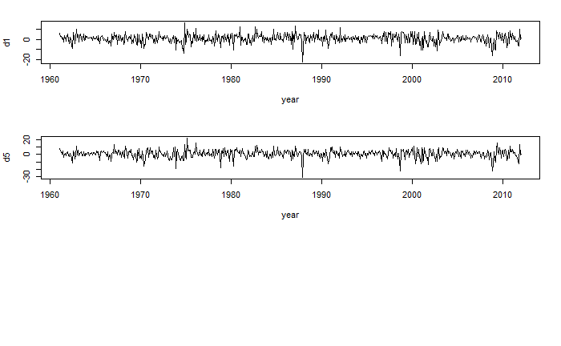

```r
plot(tdx,rtn[,3],type="l",xlab="year",ylab="d8")
```

[output not shown]

1. Especifique un modelo VMA para el retorno

Para el identificar el orden del modelo primero calcularemos la correlación-cruzada de los retornos

```
[1] "Covariance matrix:"
     [,1] [,2] [,3]
[1,] 18.4 20.2 21.8
[2,] 20.2 30.7 34.3
[3,] 21.8 34.3 41.2
CCM at lag:  0
      [,1]  [,2]  [,3]
[1,] 1.000 0.851 0.791
[2,] 0.851 1.000 0.964
[3,] 0.791 0.964 1.000
Simplified matrix:
CCM at lag:  1
. . .
+ + +
+ + +
CCM at lag:  2
. . .
. . .
. . .
CCM at lag:  3
. . .
. . .
. . .
CCM at lag:  4
. . .
. . .
. . .
CCM at lag:  5
+ . .
. . .
. . .
CCM at lag:  6
. . .
. . .
. . .
CCM at lag:  7
. . .
. . .
. . .
CCM at lag:  8
. - -
. - -
. - -
CCM at lag:  9
. . .
. . .
. . .
CCM at lag:  10
. . .
. . .
. . .
CCM at lag:  11
. . .
. . .
. . .
CCM at lag:  12
. . .
. . .
. . .
Hit Enter for p-value plot of individual ccm:
```

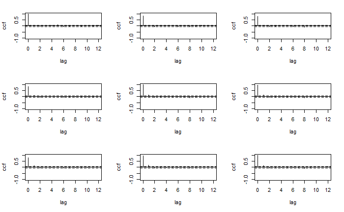

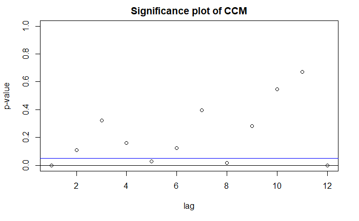

```r
ccm(rtn)
```

Gracias al gráfico de correlación cruzada de los retornos se aprecia una dependencia significativa dinámica en el **lag-1**, lo cual es un primer indicativo que un modelo **VMA(1)** seria el apropiado para estas series.No obstante se resalta que la prueba **Ljung-Box** los **lag-5** y **lag-8** tambien poseen cierta significancia.

A continuación se usan los retornos para crear a **zt** y correr el comando **VMAorder**, para especificar el orden del proceso VMA usando la prueba **Ljung-Box**

```
Q(j,m) Statistics:
         j     Q(j,m)   p-value
 [1,]   1.00    289.86     0.00
 [2,]   2.00    245.19     0.00
 [3,]   3.00    230.80     0.00
 [4,]   4.00    220.44     0.00
 [5,]   5.00    207.33     0.00
 [6,]   6.00    188.41     0.00
 [7,]   7.00    174.40     0.00
 [8,]   8.00    164.90     0.00
 [9,]   9.00    145.01     0.01
[10,]  10.00    134.08     0.01
[11,]  11.00    126.17     0.01
[12,]  12.00    119.47     0.00
[13,]  13.00     90.13     0.07
[14,]  14.00     83.01     0.05
[15,]  15.00     62.89     0.19
[16,]  16.00     46.80     0.40
[17,]  17.00     38.47     0.36
[18,]  18.00     30.68     0.28
[19,]  19.00     15.79     0.61
[20,]  20.00      8.76     0.46
```

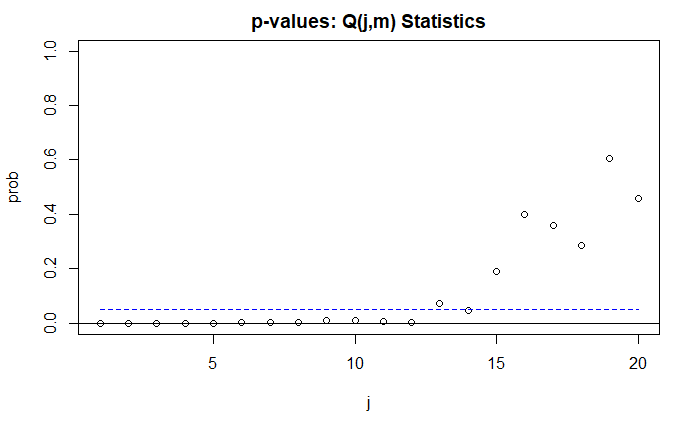

```r
zt <- rtn
VMAorder(zt,lag=20)
```

Podemos ver que se los $Q_k(1,20),...,Q_k(12,20)$, son significativos al $5%$, por lo cual los resultados no son concluyentes, sin embargo al como parte del principio de parsimonia y apoyados sobre los resultados de la correlación-cruzada, se determina que el orden del modelo es **VMA(1)**.

2. Haga la estimación del modelo con MV.

Para este punto se utiliza el comando VMA para estimar el modelo usando verosilimutd condicional Gaussiana donde $q=1$, representa el orden de nuestro modelo.

```r
VMA1 <- VMA(zt, q = 1)
```

```
Number of parameters:  12
initial estimates:  0.7025 0.8981 0.9552 0.1131 -0.2658 0.1142 0.1528 -0.5369 0.242 0.1711 -0.7186 0.3289
Par. Lower-bounds:  0.495 0.634 0.6518 0.0185 -0.4344 -0.0118 0.0324 -0.7515 0.0815 0.0327 -0.9651 0.1445
Par. Upper-bounds:  0.9099 1.1622 1.2586 0.2077 -0.0972 0.2402 0.2733 -0.3223 0.4025 0.3095 -0.472 0.5132
Final   Estimates:  0.7158762 0.9198663 0.9833664 0.07989616 -0.2626063 0.1257202 0.1041787 -0.535717 0.26051 0.1213884 -0.7180216 0.3481091

Coefficient(s):
       Estimate  Std. Error  t value Pr(>|t|)
 [1,]   0.71588     0.18333    3.905 9.43e-05 ***
 [2,]   0.91987     0.25930    3.548 0.000389 ***
 [3,]   0.98337     0.30212    3.255 0.001134 **
 [4,]   0.07990     0.07552    1.058 0.290087
 [5,]  -0.26261     0.13723   -1.914 0.055662 .
 [6,]   0.12572     0.10209    1.232 0.218133
 [7,]   0.10418     0.09690    1.075 0.282321
 [8,]  -0.53572     0.17257   -3.104 0.001907 **
 [9,]   0.26051     0.12794    2.036 0.041738 *
[10,]   0.12139     0.11230    1.081 0.279733
[11,]  -0.71802     0.20017   -3.587 0.000334 ***
[12,]   0.34811     0.14863    2.342 0.019176 *
---
Signif. codes:  0 ‘***’ 0.001 ‘**’ 0.01 ‘*’ 0.05 ‘.’ 0.1 ‘ ’ 1
---
Estimates in matrix form:
Constant term:
Estimates:  0.7158762 0.9198663 0.9833664
MA coefficient matrix
MA( 1 )-matrix
       [,1]   [,2]  [,3]
[1,] 0.0799 -0.263 0.126
[2,] 0.1042 -0.536 0.261
[3,] 0.1214 -0.718 0.348

Residuals cov-matrix:
         [,1]     [,2]     [,3]
[1,] 18.21362 19.76509 21.13788
[2,] 19.76509 29.54105 32.70033
[3,] 21.13788 32.70033 39.00978
----
aic=  6.026387
bic=  6.11299
```

Podemos decir entonces que el modelo estimado por verosimilitd condicional Gaussiana esta dado por:

$$z_t =\begin{bmatrix}
0.72
\\0.92
\\0.98
\end{bmatrix}+ a_t - \begin{bmatrix}
0.080 & -0.263 & 0.126\\
0.104 & -0.536 & 0.261\\
0.121 & -0.718 & 0.348
\end{bmatrix}a_{t-1}, \hat{\sum}_a = \begin{bmatrix}
18.214 & 19.765 & 21.138 \\
19.765 & 29.541 & 32.700 \\
21.138 & 32.700 & 39.001
\end{bmatrix}$$

3. Refine el modelo para una t mayor 1.645.

Haciendo uso del comando **refVMA** se refinara el modelo haciendo $0$ a todos aquellos parametros no significativos (inferiores) para un umbral de $1.645$.

```r
r.VMA <- refVMA(VMA1, thres = 1.645)
```

```
Number of parameters:  8
initial estimates:  0.7159 0.9199 0.9834 0.2626 0.5357 -0.2605 0.718 -0.3481
Par. Lower-bounds:  0.3492 0.4013 0.3791 -0.0118 0.1906 -0.5164 0.3177 -0.6454
Par. Upper-bounds:  1.0825 1.4385 1.5876 0.5371 0.8809 -0.0046 1.1184 -0.0508
Final   Estimates:  0.7147405 0.9180014 0.9817448 0.01265214 0.2603929 -0.2741884 0.3176887 -0.3695367

Coefficient(s):
  Estimate  Std. Error  t value Pr(>|t|)
   0.71474     0.17130    4.172 3.01e-05 ***
   0.91800     0.23515    3.904 9.46e-05 ***
   0.98174     0.28688    3.422 0.000621 ***
   0.01265     0.03280    0.386 0.699654
   0.26039     0.09348    2.786 0.005342 **
  -0.27419     0.07238   -3.788 0.000152 ***
   0.31769     0.11777    2.697 0.006987 **
  -0.36954     0.09280   -3.982 6.83e-05 ***
---
Signif. codes:  0 ‘***’ 0.001 ‘**’ 0.01 ‘*’ 0.05 ‘.’ 0.1 ‘ ’ 1
---
Estimates in matrix form:
Constant term:
Estimates:  0.7147405 0.9180014 0.9817448
MA coefficient matrix
MA( 1 )-matrix
     [,1]   [,2]   [,3]
[1,]    0 0.0127  0.000
[2,]    0 0.2604 -0.274
[3,]    0 0.3177 -0.370

Residuals cov-matrix:
         [,1]     [,2]     [,3]
[1,] 18.46597 20.24380 21.73191
[2,] 20.24380 30.78095 34.31556
[3,] 21.73191 34.31556 41.12705
----
aic=  6.098651
bic=  6.156386
```

4. Escriba el modelo ajustado

El modelo refinado esta dado entonces por:

$$z_t =\begin{bmatrix}
0.715
\\0.918
\\0.982
\end{bmatrix}+ a_t - \begin{bmatrix}
0 & 0.0127 & 0.000\\
0 & 0.2604 & -0.274\\
0 & 0.3177 & -0.370
\end{bmatrix}a_{t-1}, \hat{\sum}_a = \begin{bmatrix}
18.467 & 20.245 & 21.732 \\
20.245 & 30.781 & 34.316 \\
21.733 & 34.321 & 41.127
\end{bmatrix}$$

5. Use el modelo para pronosticar los retornos

```r
prd.VMA <- VMApred(r.VMA)
```

```
Forecasts at origin:  612
[1] 0.7165 0.8994 0.9521
Standard Errors of predictions:
[1] 4.297 5.548 6.413
```

**Tabla comparativa entre los el promedio del retorno y su estimado**

| Decil | Promedio retorno | Promedio predicción | % de diferencia |
| --- | --- | --- | --- |
| dec1 | 0.7143 | 0.7165 | 0.003 |
| dec5 | 0.9171 | 0.8994 | 0.019 |
| dec8 | 0.9805 | 0.9521 | 0.028 |

**Tabla comparativa entre la desviación estándar del retorno y su estimado**

[output not shown]

Se aprecia fatalmente que que la diferencia entre los valores estimados para el vector $\mu$, como la desviación estandár $\sigma$, no superan el $5%$ de diferencia, por lo que es posible hablar de nuestro modelo estimado se ajsuta correctamente a un proceso $VMA$ para los retornos de las acciones de las bolsas NYSE, AMEX, y NASDAQ entre 1961 y 2012.

6. Obtenga los intervalos de confianza del 95%.

Los intervalos de confianza del 95% para nuestro modelo están dados por:

**Limite superior**.

```r
upper<-prd.VMA$pred+1.96*prd.VMA$se

upper
```

```
        [,1]     [,2]     [,3]
[1,] 9.13902 11.77361 13.52163
```

**Limite inferior**.

```r
lower<-prd.VMA$pred-1.96*prd.VMA$se
lower
```

```
          [,1]      [,2]      [,3]
[1,] -7.706022 -9.974776 -11.61748
```

**Tabla de intervalos de confianza del 95 % para los retornos**.

[output not shown]

En otras palabras:

- El $95$% de los retornos estará entre $-7.706$ y $9.139$ para el decil 1.
- El $95$% de los retornos estará entre $-9.975$ y $11.774$ para el decil 5.
- El $95$% de los retornos estará entre $-11.617$ y $13.522$ para el decil 8.

Estos intervalos de confianza son bastantes amplios debido a que la desviación estandar es grandes para cada valor de $\mu$.